# AI Project 0

## Arman Rostami

In this project two methods of Regressions are implemented to predict house prices.

## Initialization

Initialy we import `numpy`, `pandas` and `matplotlib.pyplot` modules by running the command below.

```python
import numpy as np
import pandas as pd
import matplotlib.pyplot as plt
```

## Data Preparation

### Reading Data

We read houses data as pandas dataframe by running this command:

```python
data = pd.read_csv("houses.csv")
```

### View Data

panda's `head` command is used to view first top 5 rows of read data to get an initial view of the data.

```python
data.head()
```

|  | Id | MSSubClass | LotArea | LotConfig | OverallQual | LotFrontage | Neighborhood | OverallCond | BedroomAbvGr | TotRmsAbvGrd | TotalBsmtSF | YearBuilt | SalePrice |
| --- | --- | --- | --- | --- | --- | --- | --- | --- | --- | --- | --- | --- | --- |
| 0 | 1 | 60 | 8450 | Inside | 7 | 65.0 | CollgCr | 5 | 3 | 8 | 856 | 2003 | 208.5 |
| 1 | 2 | 20 | 9600 | FR2 | 6 | 80.0 | Veenker | 8 | 3 | 6 | 1262 | 1976 | 181.5 |
| 2 | 3 | 60 | 11250 | Inside | 7 | 68.0 | CollgCr | 5 | 3 | 6 | 920 | 2001 | 223.5 |
| 3 | 4 | 70 | 9550 | Corner | 7 | 60.0 | Crawfor | 5 | 3 | 7 | 756 | 1915 | 140.0 |
| 4 | 5 | 60 | 14260 | FR2 | 8 | 84.0 | NoRidge | 5 | 4 | 9 | 1145 | 2000 | 250.0 |

### Delete Categorical Columns

In this project we only use numerical values to process. there are ways to use categorical values such as assigning numerical values to them but we just delete them in this project. As can be seen in previous part there are two categorical columns named **LotConfig** and **Neighborhood**. To delete them this command is used:

```python
def delete_columns(data, columns):
    return data.drop(columns, axis = 1)
```

Results:

```python
categoricals = ["LotConfig", "Neighborhood"]
data = delete_columns(data, categoricals)
data.head()
```

|  | Id | MSSubClass | LotArea | OverallQual | LotFrontage | OverallCond | BedroomAbvGr | TotRmsAbvGrd | TotalBsmtSF | YearBuilt | SalePrice |
| --- | --- | --- | --- | --- | --- | --- | --- | --- | --- | --- | --- |
| 0 | 1 | 60 | 8450 | 7 | 65.0 | 5 | 3 | 8 | 856 | 2003 | 208.5 |
| 1 | 2 | 20 | 9600 | 6 | 80.0 | 8 | 3 | 6 | 1262 | 1976 | 181.5 |
| 2 | 3 | 60 | 11250 | 7 | 68.0 | 5 | 3 | 6 | 920 | 2001 | 223.5 |
| 3 | 4 | 70 | 9550 | 7 | 60.0 | 5 | 3 | 7 | 756 | 1915 | 140.0 |
| 4 | 5 | 60 | 14260 | 8 | 84.0 | 5 | 4 | 9 | 1145 | 2000 | 250.0 |

### Delete Missing Data

To delete missing data which is shown as **NaN** in pandas dataframe we use `DataFrame.fillna` function to fill NaN values with average of corresponding column. Average of columns is calculated by `Dataframe.mean` function which returns a pandas Series including averages of columns. code is shown below:

```python
def delete_nans(data):
    return data.fillna(data.mean())
```

results:

```python
data = delete_nans(data)
```

### Draw Scatter Diagram

Since we want to predict house prices as a dependent variable, we draw scatter diagrams using `matplotlib.pyplot` functions to better perceive the relationship of house prices and other numerical independent variables. Below function is used to draw scatter diagrams:

```python
def draw_series_scatter(x, y):
    plt.scatter(x, y)
    plt.xlabel(x.name)
    plt.ylabel(y.name)
    plt.title("%s - %s Relationship" % (x.name, y.name))
```

### Diagrams

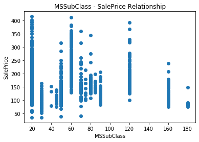

```python
draw_series_scatter(data["MSSubClass"], data["SalePrice"])
```

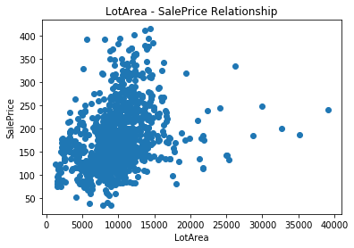

```python
draw_series_scatter(data["LotArea"], data["SalePrice"])
```

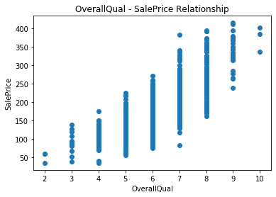

```python
draw_series_scatter(data["OverallQual"], data["SalePrice"])
```

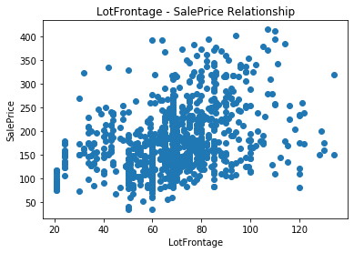

```python
draw_series_scatter(data["LotFrontage"], data["SalePrice"])
```

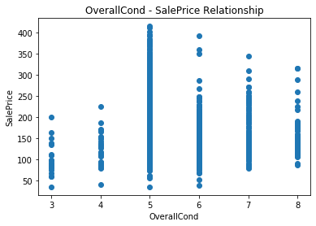

```python
draw_series_scatter(data["OverallCond"], data["SalePrice"])
```

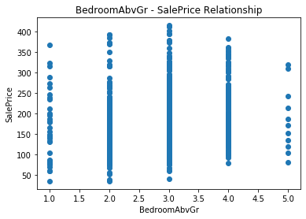

```python
draw_series_scatter(data["BedroomAbvGr"], data["SalePrice"])
```

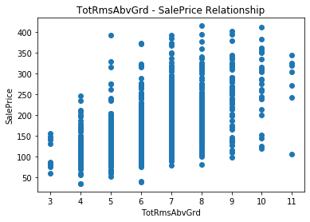

```python
draw_series_scatter(data["TotRmsAbvGrd"], data["SalePrice"])
```

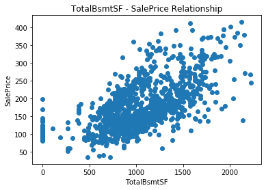

```python
draw_series_scatter(data["TotalBsmtSF"], data["SalePrice"])
```

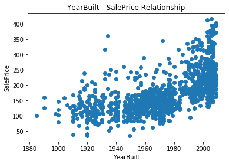

```python
draw_series_scatter(data["YearBuilt"], data["SalePrice"])
```

## Linear Regression

Linear regression is a method for modeling the relationship between one or more independent variables and a dependent variable. In simple model we assume that $\hat{y}$ is a linear function of the input variable as shown below:

$$ \hat{y} = w.x + b $$

w and b are called co-efficients and x is input. We'll try to guess co-efficients to have a better y function for predicting and minimizing the error function. In other words, we'll try to find the line which the vertical distance between line and data represented as point which is the difference between predicted and real data is minimized. There are several methods to choose co-efficients. Two methods are implemented here: **Normal Equation** and **Gradient Descent**. We'll use **TotalBsmtSF** as input since It has a better linear relationship with price based on previous part diagrams.

## Error function

We use RMSE method as error function to determine difference between real price and predicted price which is shown below:

$$ L_{RMSE} = \sqrt{\frac{1}{N}\sum_{i=1}^{N}(\hat{y}_{i} - y_{i})^2} $$

The code below shows implementation of RMSE error function:

```python
def get_rmse(y_real, y_hat):
    N = y_real.shape[0]
    return np.sqrt(np.sum(np.power(y_hat - y_real, 2)) / N)
```

### Normal Equation

In this method, we'll assume x and co-efficients as matrixes and try to solve the problem directly using a system of linear equations. In simple model which has only one independent variable we have the below formulas:

$$ \hat{y} = B.X = \begin{bmatrix} b & w \end{bmatrix} . \begin{bmatrix} 1 \\ x \end{bmatrix} $$

We'll try to solve the equation directly:

$$ \hat{y} = B.X $$

$$ X^T.\hat{y} = B.X.X^T $$

$$ B = (X.X^T)^{-1}.X^T.\hat{y} $$

Below code shows the implementation of this method:

```python
from numpy.linalg import inv

def normal_equation(data, dependent, independent):
    y_hat = np.matrix(data[independent].values).T

    X_arr = data[dependent].values
    X_size = X_arr.shape[0]
    X = np.matrix([np.ones(X_size), X_arr]).T

    B = inv(X.T.dot(X)).dot(X.T).dot(y_hat)
    w = B[1, 0]
    b = B[0, 0]

    return (w, b)
```

Results:

```python
w, b = normal_equation(data, "TotalBsmtSF", "SalePrice")

y_hat_series = w * data["TotalBsmtSF"] + b
y_hat_series.name = "PredictedSalePrice"

print("w: %s" % w)
print("b: %s" % b)
print("RMSE: %s" % get_rmse(data["SalePrice"], y_hat_series))
```

```
w: 0.10489814533423741
b: 66.52517775218885
RMSE: 51.43001839349524
```

Diagrams are shown below:

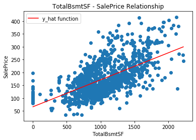

```python
line_x = np.linspace(0, max(data["TotalBsmtSF"]), 10)
line_y = np.array(w * line_x + b)
plt.plot(line_x, line_y, color = "r", label = "y_hat function")
plt.legend()
draw_series_scatter(data["TotalBsmtSF"], data["SalePrice"])
```

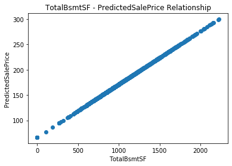

```python
draw_series_scatter(data["TotalBsmtSF"], y_hat_series)
```

### Gradient Descent

Gradient Descent is an algorithm which minimizes functions by taking steps in the negative direction of the function gradient. We start by initial set of co-efficients and iteratively move forward a set of parameters to minimize the error function. First we compute the gradient of error function:

$$ L_{RMSE} = \sqrt{\frac{1}{N}\sum_{i=1}^{N}(y_{i} - \hat{y}_{i})^2} = \sqrt{\frac{1}{N}\sum_{i=1}^{N}({y}_{i} - w.x_{i} + b)^2} $$

$$ \frac{\partial{L_{RMSE}}}{\partial w} = \frac{1}{N}. \frac{\sum_{i=1}^{N} -x_i({y}_i - (w.x_i + b)) } {\sqrt{\frac{1}{N}\sum_{i=1}^{N}(y_{i} - w.x_{i} + b)^2}} $$

$$ \frac{\partial{L_{RMSE}}}{\partial b} = \frac{1}{N}. \frac{\sum_{i=1}^{N} -(y_i - (w.x_i + b)) } {\sqrt{\frac{1}{N}\sum_{i=1}^{N}(y_{i} - w.x_{i} + b)^2}} $$

We'll use gradient of error function to change values of w and b in direction of getting less error. We also use learning rate as `lRate` which controls how much the value of w changes on each iteration. values of w and b change as follows:

$$ w = w - lRate . \frac{\partial{L_{RMSE}}}{\partial{w}} $$

$$ b = b - lRate . \frac{\partial{L_{RMSE}}}{\partial{b}} $$

Code below shows the implementation of Gradient Descent:

```python
def gradient_descent(data, dependent, independent):

    lRate = 0.0001
    lTimes = 1000
    w = 0
    b = 0

    X = data[dependent].values
    y = data[independent].values
    y_hat = 0

    N = X.shape[0]

    for i in range(lTimes):
        y_hat = w * X + b
        denominator = np.sqrt((1 / N) * sum((y - y_hat) ** 2))
        d_w = ((-1 / N) * sum(X * (y - y_hat))) / denominator
        d_b = ((-1 / N) * sum(y - y_hat)) / denominator
        w -= (lRate * d_w)
        b -= (lRate * d_b)

    return (w, b)
```

Results:

```python
w, b = gradient_descent(data, "TotalBsmtSF", "SalePrice")
y_hat_series = w * data["TotalBsmtSF"] + b
y_hat_series.name = "PredictedSalePrice"

print("w: %s" % w)
print("b: %s" % b)
print("RMSE: %s" % get_rmse(data["SalePrice"], y_hat_series))
```

```
w: 0.18166905387081272
b: 0.013542113797564537
RMSE: 60.67139206424852
```

Diagrams are shown below:

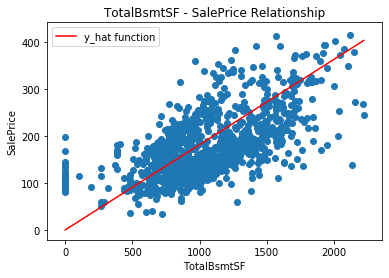

```python
line_x = np.linspace(0, max(data["TotalBsmtSF"]), 10)
line_y = np.array(w * line_x + b)
plt.plot(line_x, line_y, color = "r", label = "y_hat function")
plt.legend()
draw_series_scatter(data["TotalBsmtSF"], data["SalePrice"])
```

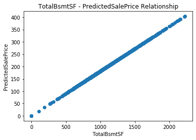

```python
draw_series_scatter(data["TotalBsmtSF"], y_hat_series)
```

## Vectorization

Previous parts are all done by vectorization. **Only loop is in Gradient Descent's learning part which is not possible to vectorize since It's updating states.**

## K-nearest Neighbours

K-nearest Neighbours is a non-parametric method to predict numerical targets. in this algorithm we'll use k nearest neighbours based on distance and report average of k neighbours's target values as goal. In this project we'll use Euclidean distance as distance function which is shown below:

$$ EuclideanDistance = \sqrt{\sum_{i=1}^{k}(x_i - y_i)^2} $$

### Standardize Distances

We standardize our training set to balance measurement scales or if we have categorical values, we'll try to standardize them to numerical values. We'll use the below formula to standardize our training set:

$$ X_s = \frac{X - Min}{Max - Min} $$

The code below shows the standardize implementation for our dataset:

```python
def standardize(data):
    Min = data.min()
    Max = data.max()
    return (data - Min) / (Max - Min)
```

### Implementation

Code below shows implemenation of KNN algorithm:

```python
def get_knn_price(single_data):

    k = 10

    clean_data = delete_columns(data, ['Id', 'SalePrice'])
    appended_data = clean_data.append(single_data, ignore_index=True)

    clean_data = standardize(appended_data)
    single_data = clean_data.iloc[-1]
    clean_data = clean_data[:-1]

    clean_array = clean_data.to_numpy()
    single_array = single_data.to_numpy()

    e_distance = np.sqrt(np.power(clean_array - single_array, 2).sum(axis = 1))

    result_data = pd.DataFrame({"EDistance": e_distance, "SalePrice": data["SalePrice"]})

    k_smallest = result_data.nsmallest(k, "EDistance")
    k_average = k_smallest["SalePrice"].mean()

    return k_average
```

Test results:

```python
train_bools = np.random.rand(len(data)) < 0.8
train_data = data[train_bools]
test_data = data[~train_bools]

test_single = test_data[0:1]
test_single_clean = delete_columns(test_single, ['Id', 'SalePrice'])

predicted_price = get_knn_price(test_single_clean)

print("Pridicted: %s" % predicted_price)
print("Sale: %s" % test_single.iloc[0]["SalePrice"])
```

```
Pridicted: 202.19400000000002
Sale: 208.5
```

Results on whole dataframe:

```
RMSE: 25.19223810272189
```

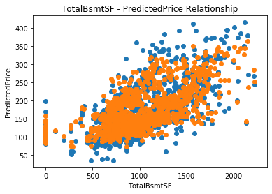

```python
test_data = delete_columns(data, ['Id', 'SalePrice'])

def test_knn(row):
    row_df = row.to_frame().transpose()
    return get_knn_price(row_df)

result = test_data.apply(test_knn, axis = 1)
result.name = "PredictedPrice"

draw_series_scatter(data["TotalBsmtSF"], data["SalePrice"])
draw_series_scatter(data["TotalBsmtSF"], result)

print("RMSE: %s" % get_rmse(data["SalePrice"], result))
```